# Risk Factor Analysis

## Outcome Variable

**Outcome Variable:** ever_stunted

## Predictor Variables

**Intervention Variable:** birthlen

**Adjustment Set:**

unadjusted

## Stratifying Variables

The analysis was stratified on these variable(s):

- agecat
- studyid

The following strata were considered:

- agecat: 12 months, studyid: ki1000108-CMC-V-BCS-2002
- agecat: 12 months, studyid: ki1000108-IRC
- agecat: 12 months, studyid: ki1000304b-SAS-CompFeed
- agecat: 12 months, studyid: ki1017093c-NIH-Crypto
- agecat: 12 months, studyid: ki1101329-Keneba
- agecat: 12 months, studyid: ki1119695-PROBIT
- agecat: 12 months, studyid: ki1126311-ZVITAMBO
- agecat: 12 months, studyid: ki1135781-COHORTS
- agecat: 12 months, studyid: kiGH5241-JiVitA-3
- agecat: 12 months, studyid: kiGH5241-JiVitA-4
- agecat: 18 months, studyid: ki1000108-CMC-V-BCS-2002
- agecat: 18 months, studyid: ki1000108-IRC
- agecat: 18 months, studyid: ki1000304b-SAS-CompFeed
- agecat: 18 months, studyid: ki1017093c-NIH-Crypto
- agecat: 18 months, studyid: ki1101329-Keneba
- agecat: 18 months, studyid: ki1119695-PROBIT
- agecat: 18 months, studyid: ki1126311-ZVITAMBO
- agecat: 18 months, studyid: ki1135781-COHORTS
- agecat: 18 months, studyid: kiGH5241-JiVitA-3
- agecat: 18 months, studyid: kiGH5241-JiVitA-4
- agecat: 24 months, studyid: ki1000108-CMC-V-BCS-2002
- agecat: 24 months, studyid: ki1000108-IRC
- agecat: 24 months, studyid: ki1000304b-SAS-CompFeed
- agecat: 24 months, studyid: ki1017093c-NIH-Crypto
- agecat: 24 months, studyid: ki1101329-Keneba
- agecat: 24 months, studyid: ki1119695-PROBIT
- agecat: 24 months, studyid: ki1126311-ZVITAMBO
- agecat: 24 months, studyid: ki1135781-COHORTS
- agecat: 24 months, studyid: kiGH5241-JiVitA-3
- agecat: 24 months, studyid: kiGH5241-JiVitA-4
- agecat: 3 months, studyid: ki1000108-CMC-V-BCS-2002
- agecat: 3 months, studyid: ki1000108-IRC
- agecat: 3 months, studyid: ki1000304b-SAS-CompFeed
- agecat: 3 months, studyid: ki1017093c-NIH-Crypto
- agecat: 3 months, studyid: ki1101329-Keneba
- agecat: 3 months, studyid: ki1119695-PROBIT
- agecat: 3 months, studyid: ki1126311-ZVITAMBO
- agecat: 3 months, studyid: ki1135781-COHORTS
- agecat: 3 months, studyid: kiGH5241-JiVitA-3
- agecat: 3 months, studyid: kiGH5241-JiVitA-4
- agecat: 6 months, studyid: ki1000108-CMC-V-BCS-2002
- agecat: 6 months, studyid: ki1000108-IRC
- agecat: 6 months, studyid: ki1000304b-SAS-CompFeed
- agecat: 6 months, studyid: ki1017093c-NIH-Crypto
- agecat: 6 months, studyid: ki1101329-Keneba
- agecat: 6 months, studyid: ki1119695-PROBIT
- agecat: 6 months, studyid: ki1126311-ZVITAMBO
- agecat: 6 months, studyid: ki1135781-COHORTS
- agecat: 6 months, studyid: kiGH5241-JiVitA-3
- agecat: 6 months, studyid: kiGH5241-JiVitA-4

### Dropped Strata

Some strata were dropped due to rare outcomes:

- agecat: 12 months, studyid: ki1000108-CMC-V-BCS-2002
- agecat: 12 months, studyid: ki1017093c-NIH-Crypto
- agecat: 12 months, studyid: ki1119695-PROBIT
- agecat: 18 months, studyid: ki1000108-CMC-V-BCS-2002
- agecat: 18 months, studyid: ki1000108-IRC
- agecat: 18 months, studyid: ki1017093c-NIH-Crypto
- agecat: 18 months, studyid: ki1119695-PROBIT
- agecat: 24 months, studyid: ki1000108-CMC-V-BCS-2002
- agecat: 24 months, studyid: ki1000108-IRC
- agecat: 24 months, studyid: ki1000304b-SAS-CompFeed
- agecat: 24 months, studyid: ki1119695-PROBIT
- agecat: 24 months, studyid: kiGH5241-JiVitA-3
- agecat: 3 months, studyid: ki1000108-CMC-V-BCS-2002
- agecat: 3 months, studyid: ki1017093c-NIH-Crypto
- agecat: 3 months, studyid: ki1119695-PROBIT
- agecat: 6 months, studyid: ki1000108-CMC-V-BCS-2002
- agecat: 6 months, studyid: ki1017093c-NIH-Crypto
- agecat: 6 months, studyid: ki1119695-PROBIT

## Methods Detail

# Results Detail

## Results Plots

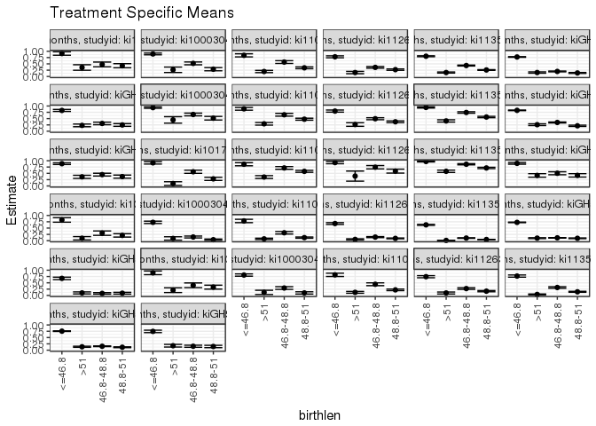

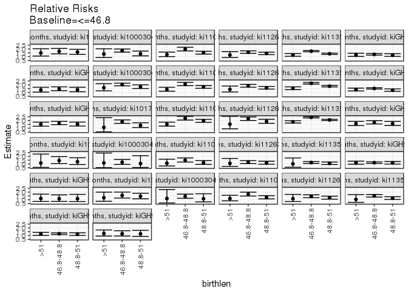

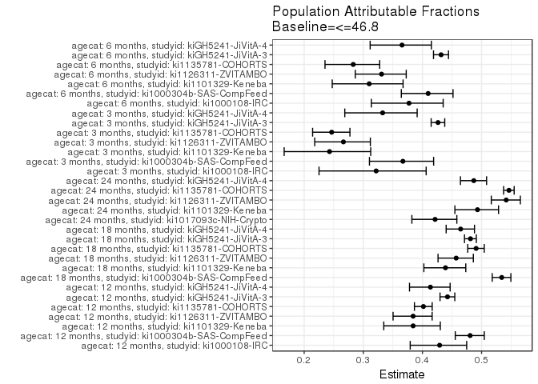

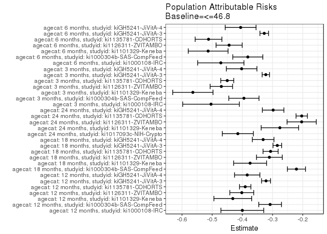

## Data Summary

| agecat | studyid | A | n | nA | nAY0 | nAY1 |
| --- | --- | --- | --- | --- | --- | --- |
| 12 months | ki1000108-CMC-V-BCS-2002 | <=46.8 | 103 | 33 | 8 | 25 |
| 12 months | ki1000108-CMC-V-BCS-2002 | >51 | 103 | 2 | 1 | 1 |
| 12 months | ki1000108-CMC-V-BCS-2002 | 46.8-48.8 | 103 | 33 | 14 | 19 |
| 12 months | ki1000108-CMC-V-BCS-2002 | 48.8-51 | 103 | 35 | 16 | 19 |
| 12 months | ki1000108-IRC | <=46.8 | 390 | 67 | 6 | 61 |
| 12 months | ki1000108-IRC | >51 | 390 | 73 | 47 | 26 |
| 12 months | ki1000108-IRC | 46.8-48.8 | 390 | 107 | 56 | 51 |
| 12 months | ki1000108-IRC | 48.8-51 | 390 | 143 | 82 | 61 |
| 12 months | ki1000304b-SAS-CompFeed | <=46.8 | 885 | 319 | 34 | 285 |
| 12 months | ki1000304b-SAS-CompFeed | >51 | 885 | 64 | 47 | 17 |
| 12 months | ki1000304b-SAS-CompFeed | 46.8-48.8 | 885 | 308 | 148 | 160 |
| 12 months | ki1000304b-SAS-CompFeed | 48.8-51 | 885 | 194 | 138 | 56 |
| 12 months | ki1017093c-NIH-Crypto | <=46.8 | 729 | 147 | 14 | 133 |
| 12 months | ki1017093c-NIH-Crypto | >51 | 729 | 68 | 65 | 3 |
| 12 months | ki1017093c-NIH-Crypto | 46.8-48.8 | 729 | 278 | 170 | 108 |
| 12 months | ki1017093c-NIH-Crypto | 48.8-51 | 729 | 236 | 203 | 33 |
| 12 months | ki1101329-Keneba | <=46.8 | 1449 | 136 | 22 | 114 |
| 12 months | ki1101329-Keneba | >51 | 1449 | 315 | 253 | 62 |
| 12 months | ki1101329-Keneba | 46.8-48.8 | 1449 | 308 | 132 | 176 |
| 12 months | ki1101329-Keneba | 48.8-51 | 1449 | 690 | 453 | 237 |
| 12 months | ki1119695-PROBIT | <=46.8 | 7943 | 31 | 3 | 28 |
| 12 months | ki1119695-PROBIT | >51 | 7943 | 4635 | 4347 | 288 |
| 12 months | ki1119695-PROBIT | 46.8-48.8 | 7943 | 241 | 86 | 155 |
| 12 months | ki1119695-PROBIT | 48.8-51 | 7943 | 3036 | 2350 | 686 |
| 12 months | ki1126311-ZVITAMBO | <=46.8 | 2516 | 437 | 96 | 341 |
| 12 months | ki1126311-ZVITAMBO | >51 | 2516 | 231 | 195 | 36 |
| 12 months | ki1126311-ZVITAMBO | 46.8-48.8 | 2516 | 829 | 530 | 299 |
| 12 months | ki1126311-ZVITAMBO | 48.8-51 | 2516 | 1019 | 743 | 276 |
| 12 months | ki1135781-COHORTS | <=46.8 | 9274 | 1823 | 359 | 1464 |
| 12 months | ki1135781-COHORTS | >51 | 9274 | 1039 | 876 | 163 |

[output cut: 170 more lines]

## Results Table

### Parameter: TSM

| agecat | studyid | intervention_level | baseline_level | estimate | ci_lower | ci_upper |
| --- | --- | --- | --- | --- | --- | --- |
| 12 months | ki1000108-IRC | <=46.8 | NA | 0.9104478 | 0.8419882 | 0.9789073 |
| 12 months | ki1000108-IRC | >51 | NA | 0.3561644 | 0.2461734 | 0.4661553 |
| 12 months | ki1000108-IRC | 46.8-48.8 | NA | 0.4766355 | 0.3818790 | 0.5713920 |
| 12 months | ki1000108-IRC | 48.8-51 | NA | 0.4265734 | 0.3454076 | 0.5077393 |
| 12 months | ki1000304b-SAS-CompFeed | <=46.8 | NA | 0.8934169 | 0.8595349 | 0.9272990 |
| 12 months | ki1000304b-SAS-CompFeed | >51 | NA | 0.2656250 | 0.1573578 | 0.3738922 |
| 12 months | ki1000304b-SAS-CompFeed | 46.8-48.8 | NA | 0.5194805 | 0.4636517 | 0.5753093 |
| 12 months | ki1000304b-SAS-CompFeed | 48.8-51 | NA | 0.2886598 | 0.2248592 | 0.3524604 |
| 12 months | ki1101329-Keneba | <=46.8 | NA | 0.8382353 | 0.7763263 | 0.9001442 |
| 12 months | ki1101329-Keneba | >51 | NA | 0.1968254 | 0.1529028 | 0.2407480 |
| 12 months | ki1101329-Keneba | 46.8-48.8 | NA | 0.5714286 | 0.5161426 | 0.6267146 |
| 12 months | ki1101329-Keneba | 48.8-51 | NA | 0.3434783 | 0.3080339 | 0.3789227 |
| 12 months | ki1126311-ZVITAMBO | <=46.8 | NA | 0.7803204 | 0.7414942 | 0.8191466 |
| 12 months | ki1126311-ZVITAMBO | >51 | NA | 0.1558442 | 0.1090615 | 0.2026268 |
| 12 months | ki1126311-ZVITAMBO | 46.8-48.8 | NA | 0.3606755 | 0.3279809 | 0.3933701 |
| 12 months | ki1126311-ZVITAMBO | 48.8-51 | NA | 0.2708538 | 0.2435626 | 0.2981449 |
| 12 months | ki1135781-COHORTS | <=46.8 | NA | 0.8030719 | 0.7848157 | 0.8213280 |
| 12 months | ki1135781-COHORTS | >51 | NA | 0.1568816 | 0.1347663 | 0.1789970 |
| 12 months | ki1135781-COHORTS | 46.8-48.8 | NA | 0.4344156 | 0.4169092 | 0.4519220 |
| 12 months | ki1135781-COHORTS | 48.8-51 | NA | 0.2581032 | 0.2432443 | 0.2729622 |
| 12 months | kiGH5241-JiVitA-3 | <=46.8 | NA | 0.7733157 | 0.7599765 | 0.7866549 |
| 12 months | kiGH5241-JiVitA-3 | >51 | NA | 0.1565452 | 0.1303805 | 0.1827099 |
| 12 months | kiGH5241-JiVitA-3 | 46.8-48.8 | NA | 0.1996874 | 0.1841976 | 0.2151771 |
| 12 months | kiGH5241-JiVitA-3 | 48.8-51 | NA | 0.1399648 | 0.1197880 | 0.1601416 |
| 12 months | kiGH5241-JiVitA-4 | <=46.8 | NA | 0.8232044 | 0.7838884 | 0.8625204 |
| 12 months | kiGH5241-JiVitA-4 | >51 | NA | 0.2310924 | 0.1775158 | 0.2846691 |
| 12 months | kiGH5241-JiVitA-4 | 46.8-48.8 | NA | 0.3081761 | 0.2574049 | 0.3589473 |
| 12 months | kiGH5241-JiVitA-4 | 48.8-51 | NA | 0.2480000 | 0.1944451 | 0.3015549 |
| 18 months | ki1000304b-SAS-CompFeed | <=46.8 | NA | 0.9352751 | 0.9078259 | 0.9627242 |
| 18 months | ki1000304b-SAS-CompFeed | >51 | NA | 0.4482759 | 0.3202133 | 0.5763384 |

[output cut: 98 more lines]

### Parameter: E(Y)

| agecat | studyid | intervention_level | baseline_level | estimate | ci_lower | ci_upper |
| --- | --- | --- | --- | --- | --- | --- |
| 12 months | ki1000108-IRC | NA | NA | 0.5102564 | 0.4917089 | 0.5288039 |
| 12 months | ki1000304b-SAS-CompFeed | NA | NA | 0.5853107 | 0.5688428 | 0.6017787 |
| 12 months | ki1101329-Keneba | NA | NA | 0.4064872 | 0.3968891 | 0.4160854 |
| 12 months | ki1126311-ZVITAMBO | NA | NA | 0.3783784 | 0.3708209 | 0.3859358 |
| 12 months | ki1135781-COHORTS | NA | NA | 0.4124434 | 0.4080766 | 0.4168102 |
| 12 months | kiGH5241-JiVitA-3 | NA | NA | 0.4516482 | 0.4452109 | 0.4580856 |
| 12 months | kiGH5241-JiVitA-4 | NA | NA | 0.4392123 | 0.4243586 | 0.4540660 |
| 18 months | ki1000304b-SAS-CompFeed | NA | NA | 0.7142857 | 0.7022537 | 0.7263177 |
| 18 months | ki1101329-Keneba | NA | NA | 0.5127831 | 0.5037708 | 0.5217953 |
| 18 months | ki1126311-ZVITAMBO | NA | NA | 0.4871935 | 0.4796151 | 0.4947718 |
| 18 months | ki1135781-COHORTS | NA | NA | 0.6362698 | 0.6304926 | 0.6420470 |
| 18 months | kiGH5241-JiVitA-3 | NA | NA | 0.5428373 | 0.5366781 | 0.5489964 |
| 18 months | kiGH5241-JiVitA-4 | NA | NA | 0.5514512 | 0.5382449 | 0.5646575 |
| 24 months | ki1017093c-NIH-Crypto | NA | NA | 0.5015773 | 0.4811290 | 0.5220256 |
| 24 months | ki1101329-Keneba | NA | NA | 0.5848043 | 0.5766524 | 0.5929562 |
| 24 months | ki1126311-ZVITAMBO | NA | NA | 0.7225806 | 0.7089655 | 0.7361958 |
| 24 months | ki1135781-COHORTS | NA | NA | 0.7666667 | 0.7622892 | 0.7710442 |
| 24 months | kiGH5241-JiVitA-4 | NA | NA | 0.5975976 | 0.5845503 | 0.6106449 |
| 3 months | ki1000108-IRC | NA | NA | 0.3196931 | 0.2957845 | 0.3436017 |
| 3 months | ki1000304b-SAS-CompFeed | NA | NA | 0.3326468 | 0.3135799 | 0.3517137 |
| 3 months | ki1101329-Keneba | NA | NA | 0.2174194 | 0.2072317 | 0.2276070 |
| 3 months | ki1126311-ZVITAMBO | NA | NA | 0.2107688 | 0.2033617 | 0.2181759 |
| 3 months | ki1135781-COHORTS | NA | NA | 0.1776765 | 0.1732506 | 0.1821024 |
| 3 months | kiGH5241-JiVitA-3 | NA | NA | 0.4032650 | 0.3979794 | 0.4085505 |
| 3 months | kiGH5241-JiVitA-4 | NA | NA | 0.2733564 | 0.2576166 | 0.2890962 |
| 6 months | ki1000108-IRC | NA | NA | 0.4241645 | 0.4018312 | 0.4464979 |
| 6 months | ki1000304b-SAS-CompFeed | NA | NA | 0.4255583 | 0.4050532 | 0.4460634 |
| 6 months | ki1101329-Keneba | NA | NA | 0.3027778 | 0.2925211 | 0.3130344 |
| 6 months | ki1126311-ZVITAMBO | NA | NA | 0.2981449 | 0.2892344 | 0.3070554 |
| 6 months | ki1135781-COHORTS | NA | NA | 0.2552172 | 0.2474517 | 0.2629828 |
| 6 months | kiGH5241-JiVitA-3 | NA | NA | 0.4251111 | 0.4189518 | 0.4312704 |
| 6 months | kiGH5241-JiVitA-4 | NA | NA | 0.3385827 | 0.3219124 | 0.3552530 |

### Parameter: RR

| agecat | studyid | intervention_level | baseline_level | estimate | ci_lower | ci_upper |
| --- | --- | --- | --- | --- | --- | --- |
| 12 months | ki1000108-IRC | >51 | <=46.8 | 1.478750 | 1.0761112 | 2.032040 |
| 12 months | ki1000108-IRC | 46.8-48.8 | <=46.8 | 1.687955 | 1.3647480 | 2.087705 |
| 12 months | ki1000108-IRC | 48.8-51 | <=46.8 | 1.597646 | 1.3020482 | 1.960353 |
| 12 months | ki1000304b-SAS-CompFeed | >51 | <=46.8 | 1.346237 | 0.8940074 | 2.027226 |
| 12 months | ki1000304b-SAS-CompFeed | 46.8-48.8 | <=46.8 | 1.788637 | 1.5959803 | 2.004549 |
| 12 months | ki1000304b-SAS-CompFeed | 48.8-51 | <=46.8 | 1.381398 | 1.1038930 | 1.728666 |
| 12 months | ki1101329-Keneba | >51 | <=46.8 | 1.264668 | 0.9997497 | 1.599784 |
| 12 months | ki1101329-Keneba | 46.8-48.8 | <=46.8 | 1.977245 | 1.7506474 | 2.233172 |
| 12 months | ki1101329-Keneba | 48.8-51 | <=46.8 | 1.506461 | 1.3269249 | 1.710290 |
| 12 months | ki1126311-ZVITAMBO | >51 | <=46.8 | 1.221059 | 0.9007151 | 1.655334 |
| 12 months | ki1126311-ZVITAMBO | 46.8-48.8 | <=46.8 | 1.587586 | 1.4316226 | 1.760541 |
| 12 months | ki1126311-ZVITAMBO | 48.8-51 | <=46.8 | 1.414967 | 1.2645677 | 1.583253 |
| 12 months | ki1135781-COHORTS | >51 | <=46.8 | 1.215739 | 1.0539681 | 1.402339 |
| 12 months | ki1135781-COHORTS | 46.8-48.8 | <=46.8 | 1.717625 | 1.6399632 | 1.798964 |
| 12 months | ki1135781-COHORTS | 48.8-51 | <=46.8 | 1.379050 | 1.2962810 | 1.467104 |
| 12 months | kiGH5241-JiVitA-3 | >51 | <=46.8 | 1.224379 | 1.0350063 | 1.448401 |
| 12 months | kiGH5241-JiVitA-3 | 46.8-48.8 | <=46.8 | 1.294627 | 1.1957308 | 1.401702 |
| 12 months | kiGH5241-JiVitA-3 | 48.8-51 | <=46.8 | 1.198407 | 1.0364571 | 1.385662 |
| 12 months | kiGH5241-JiVitA-4 | >51 | <=46.8 | 1.324087 | 1.0449971 | 1.677714 |
| 12 months | kiGH5241-JiVitA-4 | 46.8-48.8 | <=46.8 | 1.454063 | 1.2248655 | 1.726148 |
| 12 months | kiGH5241-JiVitA-4 | 48.8-51 | <=46.8 | 1.351563 | 1.0833915 | 1.686115 |
| 18 months | ki1000304b-SAS-CompFeed | >51 | <=46.8 | 1.614941 | 1.2118120 | 2.152177 |
| 18 months | ki1000304b-SAS-CompFeed | 46.8-48.8 | <=46.8 | 2.032370 | 1.8644730 | 2.215387 |
| 18 months | ki1000304b-SAS-CompFeed | 48.8-51 | <=46.8 | 1.735828 | 1.5076388 | 1.998554 |
| 18 months | ki1101329-Keneba | >51 | <=46.8 | 1.392454 | 1.1574126 | 1.675227 |
| 18 months | ki1101329-Keneba | 46.8-48.8 | <=46.8 | 2.086720 | 1.8802637 | 2.315844 |
| 18 months | ki1101329-Keneba | 48.8-51 | <=46.8 | 1.711669 | 1.5473735 | 1.893408 |
| 18 months | ki1126311-ZVITAMBO | >51 | <=46.8 | 1.394562 | 1.0601236 | 1.834505 |
| 18 months | ki1126311-ZVITAMBO | 46.8-48.8 | <=46.8 | 1.860230 | 1.6908178 | 2.046618 |
| 18 months | ki1126311-ZVITAMBO | 48.8-51 | <=46.8 | 1.598394 | 1.4343961 | 1.781143 |

[output cut: 66 more lines]

### Parameter: PAR

| agecat | studyid | intervention_level | baseline_level | estimate | ci_lower | ci_upper |
| --- | --- | --- | --- | --- | --- | --- |
| 12 months | ki1000108-IRC | <=46.8 | NA | -0.4001913 | -0.4711189 | -0.3292638 |
| 12 months | ki1000304b-SAS-CompFeed | <=46.8 | NA | -0.3081062 | -0.3457783 | -0.2704341 |
| 12 months | ki1101329-Keneba | <=46.8 | NA | -0.4317481 | -0.4943966 | -0.3690995 |
| 12 months | ki1126311-ZVITAMBO | <=46.8 | NA | -0.4019420 | -0.4414969 | -0.3623871 |
| 12 months | ki1135781-COHORTS | <=46.8 | NA | -0.3906285 | -0.4093996 | -0.3718573 |
| 12 months | kiGH5241-JiVitA-3 | <=46.8 | NA | -0.3216675 | -0.3364788 | -0.3068562 |
| 12 months | kiGH5241-JiVitA-4 | <=46.8 | NA | -0.3839921 | -0.4260204 | -0.3419638 |
| 18 months | ki1000304b-SAS-CompFeed | <=46.8 | NA | -0.2209894 | -0.2509598 | -0.1910190 |
| 18 months | ki1101329-Keneba | <=46.8 | NA | -0.3744350 | -0.4289643 | -0.3199057 |
| 18 months | ki1126311-ZVITAMBO | <=46.8 | NA | -0.3105273 | -0.3532403 | -0.2678144 |
| 18 months | ki1135781-COHORTS | <=46.8 | NA | -0.3065874 | -0.3315857 | -0.2815890 |
| 18 months | kiGH5241-JiVitA-3 | <=46.8 | NA | -0.2843120 | -0.2985822 | -0.2700419 |
| 18 months | kiGH5241-JiVitA-4 | <=46.8 | NA | -0.3312304 | -0.3670991 | -0.2953617 |
| 24 months | ki1017093c-NIH-Crypto | <=46.8 | NA | -0.4150894 | -0.4665161 | -0.3636626 |
| 24 months | ki1101329-Keneba | <=46.8 | NA | -0.2758514 | -0.3378640 | -0.2138389 |
| 24 months | ki1126311-ZVITAMBO | <=46.8 | NA | -0.2036489 | -0.2520378 | -0.1552599 |
| 24 months | ki1135781-COHORTS | <=46.8 | NA | -0.2034826 | -0.2222272 | -0.1847379 |
| 24 months | kiGH5241-JiVitA-4 | <=46.8 | NA | -0.2981079 | -0.3337748 | -0.2624410 |
| 3 months | ki1000108-IRC | <=46.8 | NA | -0.5038363 | -0.5976584 | -0.4100142 |
| 3 months | ki1000304b-SAS-CompFeed | <=46.8 | NA | -0.3948813 | -0.4449292 | -0.3448335 |
| 3 months | ki1101329-Keneba | <=46.8 | NA | -0.5640376 | -0.6307557 | -0.4973195 |
| 3 months | ki1126311-ZVITAMBO | <=46.8 | NA | -0.4696764 | -0.5068678 | -0.4324849 |
| 3 months | ki1135781-COHORTS | <=46.8 | NA | -0.4501150 | -0.4716814 | -0.4285487 |
| 3 months | kiGH5241-JiVitA-3 | <=46.8 | NA | -0.3224239 | -0.3346329 | -0.3102150 |
| 3 months | kiGH5241-JiVitA-4 | <=46.8 | NA | -0.4024678 | -0.4530826 | -0.3518530 |
| 6 months | ki1000108-IRC | <=46.8 | NA | -0.4713579 | -0.5480195 | -0.3946963 |
| 6 months | ki1000304b-SAS-CompFeed | <=46.8 | NA | -0.3820018 | -0.4317463 | -0.3322573 |
| 6 months | ki1101329-Keneba | <=46.8 | NA | -0.5133987 | -0.5793226 | -0.4474748 |
| 6 months | ki1126311-ZVITAMBO | <=46.8 | NA | -0.4439476 | -0.4871801 | -0.4007151 |
| 6 months | ki1135781-COHORTS | <=46.8 | NA | -0.5120958 | -0.5563775 | -0.4678141 |
| 6 months | kiGH5241-JiVitA-3 | <=46.8 | NA | -0.3275624 | -0.3417280 | -0.3133968 |
| 6 months | kiGH5241-JiVitA-4 | <=46.8 | NA | -0.4058263 | -0.4569665 | -0.3546861 |

### Parameter: PAF

| agecat | studyid | intervention_level | baseline_level | estimate | ci_lower | ci_upper |
| --- | --- | --- | --- | --- | --- | --- |
| 12 months | ki1000108-IRC | <=46.8 | NA | 0.4290454 | 0.3793123 | 0.4747936 |
| 12 months | ki1000304b-SAS-CompFeed | <=46.8 | NA | 0.4806292 | 0.4555157 | 0.5045845 |
| 12 months | ki1101329-Keneba | <=46.8 | NA | 0.3842610 | 0.3346175 | 0.4302007 |
| 12 months | ki1126311-ZVITAMBO | <=46.8 | NA | 0.3842420 | 0.3503265 | 0.4163870 |
| 12 months | ki1135781-COHORTS | <=46.8 | NA | 0.4016517 | 0.3864568 | 0.4164702 |
| 12 months | kiGH5241-JiVitA-3 | <=46.8 | NA | 0.4423597 | 0.4297412 | 0.4546990 |
| 12 months | kiGH5241-JiVitA-4 | <=46.8 | NA | 0.4134749 | 0.3781266 | 0.4468139 |
| 18 months | ki1000304b-SAS-CompFeed | <=46.8 | NA | 0.5340688 | 0.5180322 | 0.5495718 |
| 18 months | ki1101329-Keneba | <=46.8 | NA | 0.4389624 | 0.4024128 | 0.4732765 |
| 18 months | ki1126311-ZVITAMBO | <=46.8 | NA | 0.4570466 | 0.4263809 | 0.4860730 |
| 18 months | ki1135781-COHORTS | <=46.8 | NA | 0.4907578 | 0.4766394 | 0.5044954 |
| 18 months | kiGH5241-JiVitA-3 | <=46.8 | NA | 0.4812197 | 0.4711314 | 0.4911156 |
| 18 months | kiGH5241-JiVitA-4 | <=46.8 | NA | 0.4646022 | 0.4401090 | 0.4880239 |
| 24 months | ki1017093c-NIH-Crypto | <=46.8 | NA | 0.4214181 | 0.3821507 | 0.4581900 |
| 24 months | ki1101329-Keneba | <=46.8 | NA | 0.4931230 | 0.4548597 | 0.5287006 |
| 24 months | ki1126311-ZVITAMBO | <=46.8 | NA | 0.5416542 | 0.5164376 | 0.5655558 |
| 24 months | ki1135781-COHORTS | <=46.8 | NA | 0.5462716 | 0.5372743 | 0.5550939 |
| 24 months | kiGH5241-JiVitA-4 | <=46.8 | NA | 0.4868468 | 0.4642930 | 0.5084511 |
| 3 months | ki1000108-IRC | <=46.8 | NA | 0.3217225 | 0.2251197 | 0.4062820 |
| 3 months | ki1000304b-SAS-CompFeed | <=46.8 | NA | 0.3669645 | 0.3103756 | 0.4189098 |
| 3 months | ki1101329-Keneba | <=46.8 | NA | 0.2428721 | 0.1661568 | 0.3125294 |
| 3 months | ki1126311-ZVITAMBO | <=46.8 | NA | 0.2663706 | 0.2178345 | 0.3118949 |
| 3 months | ki1135781-COHORTS | <=46.8 | NA | 0.2464940 | 0.2142955 | 0.2773731 |
| 3 months | kiGH5241-JiVitA-3 | <=46.8 | NA | 0.4263292 | 0.4147142 | 0.4377137 |
| 3 months | kiGH5241-JiVitA-4 | <=46.8 | NA | 0.3326753 | 0.2686953 | 0.3910579 |
| 6 months | ki1000108-IRC | <=46.8 | NA | 0.3772751 | 0.3135982 | 0.4350447 |
| 6 months | ki1000304b-SAS-CompFeed | <=46.8 | NA | 0.4096076 | 0.3642815 | 0.4517021 |
| 6 months | ki1101329-Keneba | <=46.8 | NA | 0.3099360 | 0.2474513 | 0.3672326 |
| 6 months | ki1126311-ZVITAMBO | <=46.8 | NA | 0.3308603 | 0.2863742 | 0.3725732 |
| 6 months | ki1135781-COHORTS | <=46.8 | NA | 0.2829514 | 0.2352156 | 0.3277077 |
| 6 months | kiGH5241-JiVitA-3 | <=46.8 | NA | 0.4315270 | 0.4187093 | 0.4440620 |
| 6 months | kiGH5241-JiVitA-4 | <=46.8 | NA | 0.3654469 | 0.3115651 | 0.4151115 |